# ettain group

Shyni

3/4/2020

The attached data set contains inventory accuracy records from a number of Grocery stores. The ‘adjustment unit quantity’ is the unit variance that 3rd party auditors confirmed upon visiting a store, e.g., the first example below (-1) means that the auditing company found one less bowl of tropical fruit than the stores perpetual inventory had on record. The subsequent example (+14) means that the auditors counted fourteen more peach fruit bowls than the stores perpetual inventory. Your objective is to work the data set in R: i) 3 ‘actionable’ insights on inventory accuracy (by store, commodity, variance amounts, etc..) ii) Plots with supporting insights that visualize your story in ggplot

Set Library

```r
library(readr)
library(tidyverse)
library(lubridate)
library(sqldf)
```

```r
library(readxl)
library(ggplot2)
```

Import Data

```r
data_xlsb <- read_excel("~/Desktop/InventoryData.xlsx")
data1 <- data_xlsb
```

Data Wrangling

```r
colnames(data1)[colnames(data1)=="Store #"] <- "Store_number"
colnames(data1)[colnames(data1)=="Commodity Name" ] <- "Commodity_Name"
colnames(data1)[colnames(data1)=="Base GTIN Number"] <- "Base_GTIN_Number"
colnames(data1)[colnames(data1)=="Base GTIN Description"] <- "Base_GTIN_Description"
colnames(data1)[colnames(data1)=="Adjustment Unit Quantity"] <- "Adjustment_Unit_Quantity"
```

Data Analysis

```r
# get maximum, minimum and median for commodity
y <- sqldf("select max(Adjustment_Unit_Quantity)  as maxAdjQty, median(Adjustment_Unit_Quantity)  as medAdjQty, min(Adjustment_Unit_Quantity) as minAdjQty, store_number, commodity_name, Base_GTIN_Number from data1 group by Store_number")

y5 <- y%>% unite("St_Co", Store_number, Commodity_Name, sep="-")
y6 <- y5[,-5]
y7 <- gather(y6, Commodity, measure, -4)
y8 <- y7[,-2]
#drop Store and GTTN number
y1 <- y[, -c(5,6)]

# gather rows for commodity (max, min and median)
y2 <- gather(y1, Commodity, measure, -4)

y3 <- y2[,-2]

y3$Store_number <- as.numeric(y3$Store_number)
```

Data VISUALIZATION

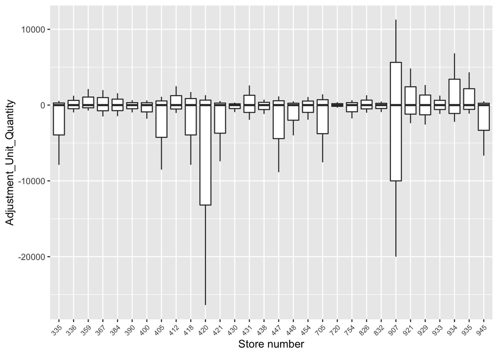

```r
#boxplot
y3 %>% ggplot(aes(x= reorder(Store_number, measure, FUN = median), y = measure)) + geom_boxplot() + theme(plot.title = element_text(size =10),axis.text.x = element_text(size =7,angle = 45, hjust = 1))+xlab("Store number") + ylab("Adjustment_Unit_Quantity")
```

The graph shows the maximum, minimum and medain values of the unit variations by Store number.  
Store 420 followed by store 907 has the maximum value for a commodity of negative variation from the stores perpetual value.  
Store 907 has the maximum value for a commodity of positive variation from stores perpetual value.  
Store 720 has the least variations in the commodities from stores perpetual values.

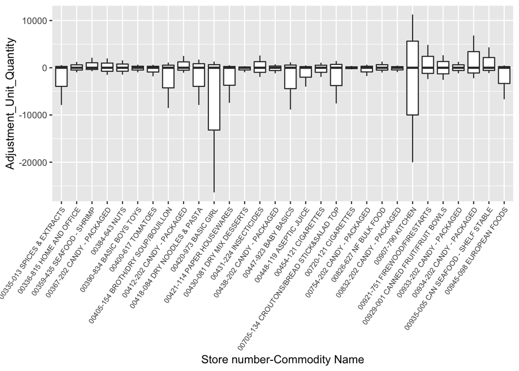

```r
y8 %>% ggplot(aes(x= reorder(St_Co, measure, FUN = median), y = measure)) + geom_boxplot() + theme(plot.title = element_text(size =10),axis.text.x = element_text(size =7,angle = 55 , hjust = 1))+xlab("Store number-Commodity Name") + ylab("Adjustment_Unit_Quantity")
```

```r
#sqldf("select * from data1 where commodity_name like '%013 SPICES & EXTRACTS%'")
```

The graph shows the maximum, minimum and medain values of the unit variations by Store number and Commodity name. Store 420 has the maximum value for a commodity- ‘973 Basic Girl’ of negative variation from the stores perpetual value. This is followed by Store 907, commodity -‘790 Kitchen’  
Store 907 has the maximum value for a commodity - ‘790 Kitchen’ of positive variation from stores perpetual value. Store 720 - ‘121 Cigerettes’ has the least variations in the commodities from stores perpetual values.

Data Analysis

```r
#get total variations by commosity
data2 <- data1 %>% group_by(Commodity_Name, Base_GTIN_Description ) %>% summarize(Adj_Qty = sum(Adjustment_Unit_Quantity))

data20 <- data1 %>% group_by(Commodity_Name  ) %>% summarize(Adj_Qty = sum(Adjustment_Unit_Quantity))

#get total variations by commodity
data9 <- data1 %>% group_by(Store_number,Commodity_Name) %>% summarize(Adj_Qty = sum(Adjustment_Unit_Quantity))
```

Data Visualization

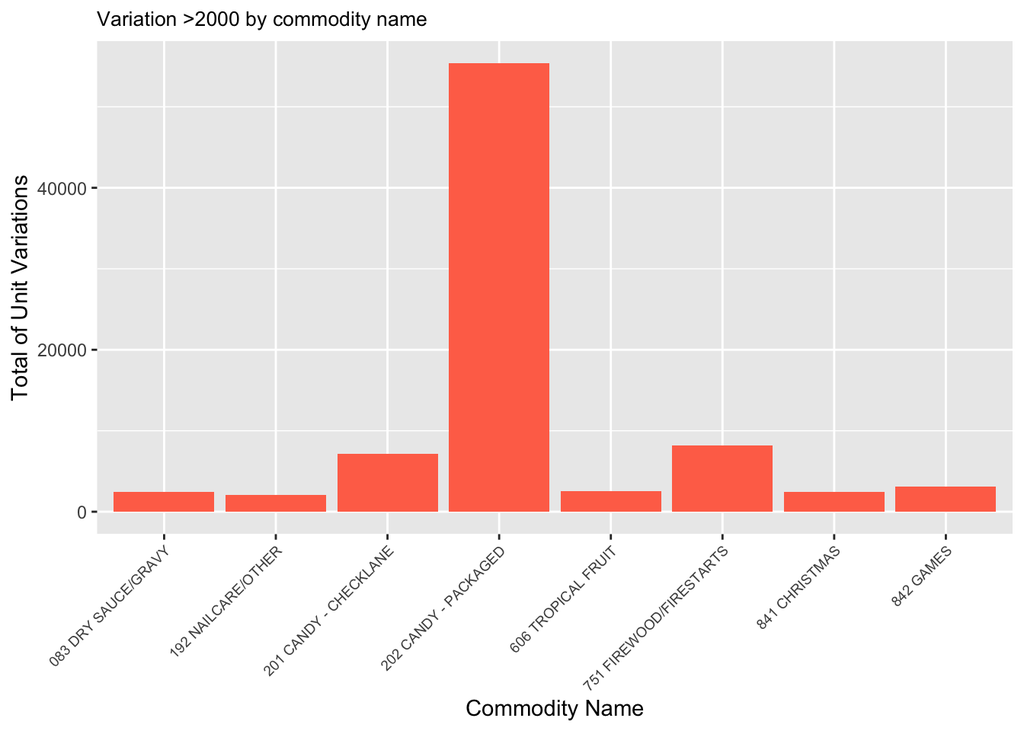

```r
data3 <- data2 %>% filter( Adj_Qty >2000)

data3 %>%
ggplot(aes(x=Commodity_Name, Adj_Qty)) + geom_bar(stat = 'identity', fill = "coral1") + ggtitle("Variation >2000 by commodity name") + theme(plot.title = element_text(size =10),axis.text.x = element_text(size =7,angle = 45, hjust = 1))  + xlab("Commodity Name") +ylab("Total of Unit Variations")
```

For all the stores, Total of positive Unit variations is the maximum for Commodity - 202- Candy-Packaged, followed by 751 Firewoodfirestarts and 210-candy-checklane, when grouped by Commodity name and GTTN description.

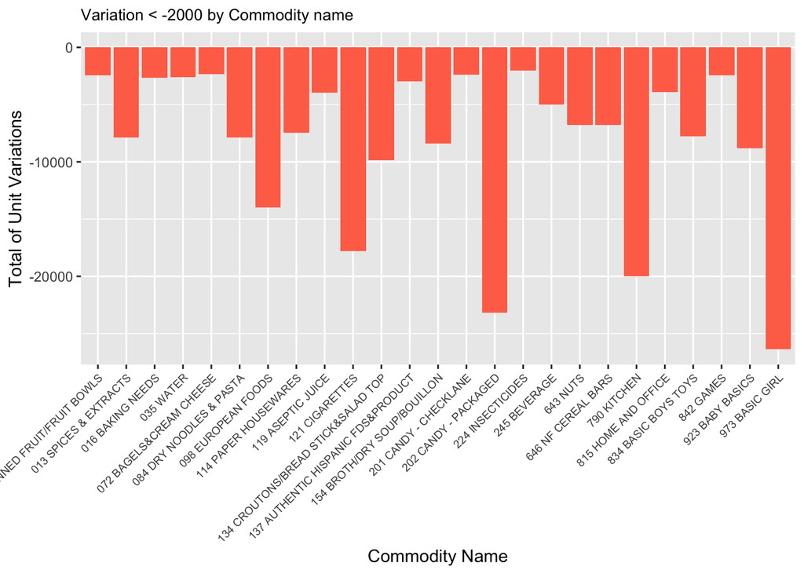

```r
data4 <- data2 %>% filter( Adj_Qty < -2000)

data4 %>%
ggplot(aes(x =  Commodity_Name, Adj_Qty)) + geom_bar(stat = 'identity', fill = "coral1") + ggtitle("Variation < -2000 by Commodity name")  + theme(plot.title = element_text(size =10),axis.text.x = element_text(size =7,angle = 45, hjust = 1))  + xlab("Commodity Name") +ylab("Total of Unit Variations")
```

For all the stores, Total of negative variations is maximum for commodity - ‘973 Basic Girl’ followed by ‘202 Candy Packaged’, ‘790 Kitchen’ ‘121- Cigerattes and ’098 European Foods’, when grouped by Commodity and GTTN number.

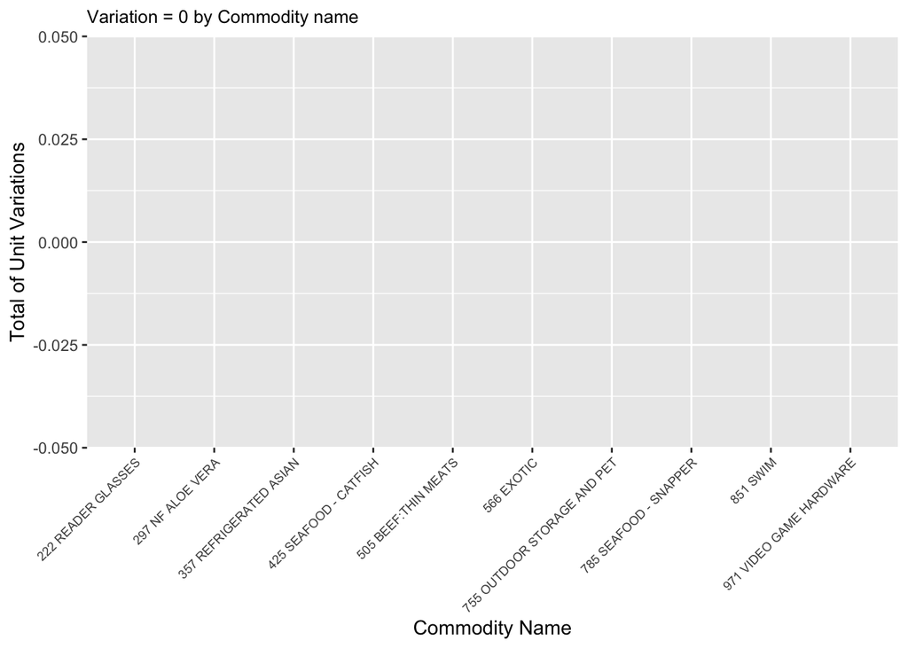

```r
#statistics in variation of commodities for a whole sale supplier to the stores
data6 <- data20 %>% filter( Adj_Qty == 0)

data6 %>%
ggplot(aes(x =  Commodity_Name, Adj_Qty)) + geom_bar(stat = 'identity', fill = "coral1") + ggtitle("Variation = 0 by Commodity name") +   theme(plot.title = element_text(size =10),axis.text.x = element_text(size =7,angle = 45, hjust = 1))  + xlab("Commodity Name") +ylab("Total of Unit Variations")
```

For all the stores, the commodities as in the figure has a total of Zero variations in all.

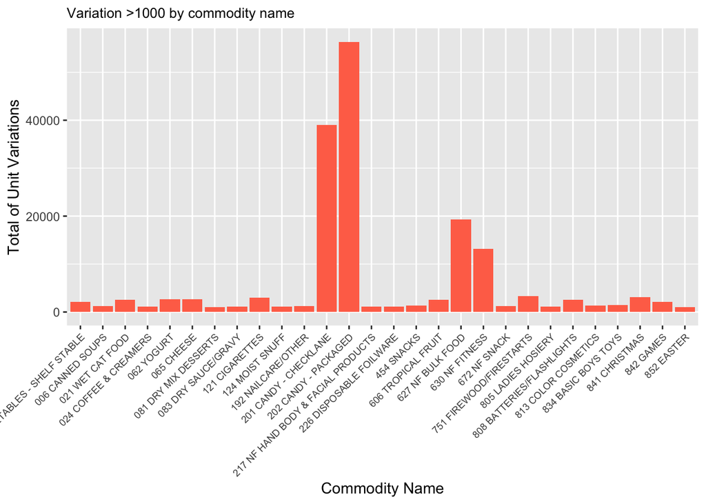

```r
data3 <- data9 %>% filter( Adj_Qty >1000)

data3 %>%
ggplot(aes(x=Commodity_Name, Adj_Qty)) + geom_bar(stat = 'identity', fill = "coral1") + ggtitle("Variation >1000 by commodity name")   + theme(plot.title = element_text(size =10),axis.text.x = element_text(size =7,angle = 45, hjust = 1))  + xlab("Commodity Name") +ylab("Total of Unit Variations")
```

For all the stores, positive Total of Unit variations is the maximum for Commodity - 202- Candy-Packaged, followed by 201-candy-checklane, when grouped by Commodity name.  
637 Bulk foo and 630 NF Fitness also has high total of positive variations.

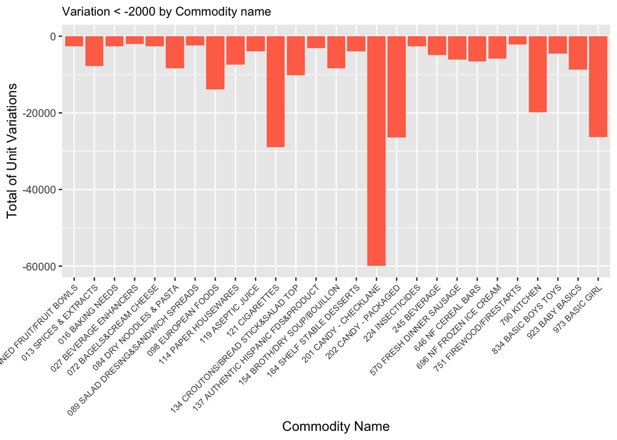

```r
data4 <- data9 %>% filter( Adj_Qty < -2000)

data4 %>%
ggplot(aes(x =  Commodity_Name, Adj_Qty)) + geom_bar(stat = 'identity', fill = "coral1") + ggtitle("Variation < -2000 by Commodity name")  + theme(plot.title = element_text(size =10),axis.text.x = element_text(size =7,angle = 45, hjust = 1))  + xlab("Commodity Name") +ylab("Total of Unit Variations")
```

For all the stores, negative Total of Unit variations is the maximum for Commodity - 201- Candy checklane, followed by 121-cigarettes, when grouped by Commodity name.  
202 Candy packaged and 973 basic girl also has high total of negative variations.

Box plot shows the variations by Store. The total of unit variations will be good measure of assessment for the wholesale dealers for these stores.

Variance of Sample

```r
data50 <- data1 %>% mutate(adjSq = Adjustment_Unit_Quantity ^2)

sumsq <-   sum(data50$adjSq, na.rm=TRUE)

sample_variance = sumsq/(nrow(data1) -1)
x <- round(sample_variance, 2)
paste(" Variance for all the stores from perpetual value is",x)
```

```
## [1] " Variance for all the stores from perpetual value is 3000.44"
```

```r
sample_stddev <- sqrt(sample_variance)
y <- round(sample_stddev, 2)
paste("Standard  deviation for all the stores from perpetual value  is", y)
```

```
## [1] "Standard  deviation for all the stores from perpetual value  is 54.78"
```